# Optimal Warping Path Costs via Dynamic Programing

## aka "Dynamic Time Warping"

For more information on the theory behind algorithms like this, check out [this module](https://ursinus-cs371-s2021.github.io/Modules/Module10/Video0) and [this module](https://ursinus-cs371-s2021.github.io/Modules/Module11/Video0) from my algorithms class

```python
import numpy as np
import matplotlib.pyplot as plt
import librosa
import IPython.display as ipd
import linmdtw # pip install linmdtw

def get_csm_fast(Y1, Y2):
    Y1Sqr = np.sum(Y1**2, 1)
    Y2Sqr = np.sum(Y2**2, 1)
    D = Y1Sqr[:, None] + Y2Sqr[None, :] - 2*Y1.dot(Y2.T)
    D[D < 0] = 0
    D = np.sqrt(D)
    return D

N = 100
t = np.linspace(0, 1, N)
Y1 = np.zeros((N, 2))
Y1[:, 0] = np.cos(2*np.pi*t)
Y1[:, 1] = np.sin(4*np.pi*t)
Y2 = np.zeros((N, 2))
Y2[:, 0] = 1.3*np.cos(2*np.pi*(t**2))
Y2[:, 1] = 1.3*np.sin(4*np.pi*(t**2))+0.1
```

## Lemma: Dynamic Programming Subproblem Cost

Let's consider a cross-similarity matrix $C$. Let's consider the minimum cost warping path that starts at $[0, 0]$ and ends at $[i, j]$. We'll call the optimal cost over all such warping paths $S_{ij}$. Then the following recurrence relation can be used to compute $S_{ij}$

### $S_{ij} = \min \left\{ \begin{array}{c} S_{i-1, j} \\ S_{i, j-1} \\ S_{i-1, j-1} \end{array} \right\} + C_{ij} $

What I'm looking for in the end is $S_{M-1, N-1}$, which will give me the optimal cost of aligning the entire first point cloud to entire second point cloud. To do this, I have to fill in the entire $S$ table row by row, and then I can look at the lower right element of $S$

```python
C = get_csm_fast(Y1, Y2)
M = C.shape[0] # Number of rows
N = C.shape[1] # Number of columns
S = np.zeros_like(C)
S[0, 0] = C[0, 0] # Base case
# First row; all warping paths that only match a single element of the first point cloud
# to some number of elements in the second point cloud
"""
for j in range(1, N):
    S[0, j] = S[0, j-1] + C[0, j]
"""
S[0, :] = np.cumsum(C[0, :])

# First column; all warping paths that only match a single element of the second point cloud
# to some number of elements in the first point cloud
S[:, 0] = np.cumsum(C[:, 0])

# For the rest of the elements, we can apply the recurrence relation above
for i in range(1, M):
    for j in range(1, N):
        S[i, j] = min(S[i-1, j], S[i, j-1], S[i-1, j-1]) + C[i, j]
```

```
30.489092600824907
```

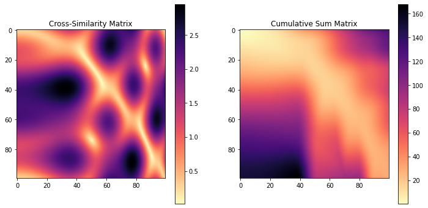

```python
plt.figure(figsize=(12, 6))
plt.subplot(121)
plt.imshow(C, cmap='magma_r')
plt.colorbar()
plt.title("Cross-Similarity Matrix")
plt.subplot(122)
plt.imshow(S, cmap='magma_r')
plt.title("Cumulative Sum Matrix")
plt.colorbar()
print(S[-1, -1])
```

Just to show you that this gives the correct answer, let's compare it to the cost we get from the warping path that linmdtw gives us

```python
import linmdtw
path = linmdtw.linmdtw(Y1, Y2)
cost = 0
for i, j in path:
    cost += C[i, j]
print(cost)
```

```
30.489092600824907
```